# Computational Text Analysis - Exercise 3: Comparison and complexity

Luca Neuperti

25/02/2026

## Introduction

The hands-on exercise for this week focuses on: 1) comparing texts; 2) measuring he document-level characteristics of text—here, complexity.

In this exercise, you will learn how to:

- Compare texts using character-based measures of similarity and distance
- Compare texts using term-based measures of similarity and distance
- Calculate the complexity of texts
- Replicate analyses from @schoonvelde_liberals_2019

## Setup

Before proceeding, we’ll load the remaining packages we will need for this exercise.

```r
library(readr) # more informative and easy way to import data
library(quanteda) # includes functions to implement Lexicoder
library(quanteda.textstats) # for estimating similarity and complexity measures
library(stringdist) # for basic character-based distance measures
library(dplyr) #for wrangling data
library(tibble) #for wrangling data
library(ggplot2) #for visualization
```

For this example we’ll be using data from the 2017-2018 Theresa May Cabinet in the UK. The data are tweets by members of this cabinet.

```r
tweets  <- readRDS(gzcon(url("https://github.com/cjbarrie/CTA-ED/blob/main/data/comparison-complexity/cabinet_tweets.rds?raw=true")))
```

And we see that the data contain three variables: “username,” which is the username of the MP in question; “tweet,” which is the text of the given tweet, and “date” in days in yyyy-mm-dd format.

```r
head(tweets)
```

```
## # A tibble: 6 × 3
##   username   tweet                                                    date
##   <chr>      <chr>                                                    <date>
## 1 aluncairns "A good luck message to Chris Coleman’s squad @FAWales … 2017-10-09
## 2 aluncairns ".@AlunCairns “The close relationship between industry … 2017-10-09
## 3 aluncairns "@BarclaysCorp &amp; @SPTS_Tech \"voice of Welsh Manufa… 2017-10-09
## 4 aluncairns "Today we announced plans to ban the sale of ivory in t… 2017-10-06
## 5 aluncairns "Unbeaten Wales overcome Georgia to boost their @FIFAWo… 2017-10-06
## 6 aluncairns ".@GutoAberconwy marks 25 years of engine production @t… 2017-10-06
```

And there are 24 MPs whose tweets we’re examining.

```r
unique(tweets$username)
```

```
##  [1] "aluncairns"      "amberrudduk"     "andrealeadsom"   "borisjohnson"
##  [5] "brandonlewis"    "damiangreen"     "damianhinds"     "daviddavismp"
##  [9] "davidgauke"      "davidmundelldct" "dlidington"      "gavinwilliamson"
## [13] "gregclarkmp"     "jbrokenshire"    "jeremy_hunt"     "juliansmithuk"
## [17] "justinegreening" "liamfox"         "michaelgove"     "pennymordaunt"
## [21] "philiphammonduk" "sajidjavid"      "theresa_may"     "trussliz"
```

```r
length(unique(tweets$username))
```

```
## [1] 24
```

## Generate document feature matrix

In order to use the `quanteda` package and its accompanying `quanteda.textstats` package, we need to reformat the data into a quanteda “corpus” object. To do this we just need to specify the text we’re interested in as well as any associated document-level variables in which we’re interested.

We can do this as follows.

```r
#make corpus object, specifying tweet as text field
tweets_corpus <- corpus(tweets, text_field = "tweet")

#add in username document-level information
docvars(tweets_corpus, "username") <- tweets$username

tweets_corpus
```

```
## Corpus consisting of 10,321 documents and 2 docvars.
## text1 :
## "A good luck message to Chris Coleman’s squad @FAWales ahead ..."
##
## text2 :
## ".@AlunCairns “The close relationship between industry and go..."
##
## text3 :
## "@BarclaysCorp &amp; @SPTS_Tech "voice of Welsh Manufacturing..."
##
## text4 :
## "Today we announced plans to ban the sale of ivory in the UK...."
##
## text5 :
## "Unbeaten Wales overcome Georgia to boost their @FIFAWorldCup..."
##
## text6 :
## ".@GutoAberconwy marks 25 years of engine production @toyotaf..."
##
## [ reached max_ndoc ... 10,315 more documents ]
```

We are now ready to reformat the data into a document feature matrix.

```r
dfmat <- dfm(tokens(tweets_corpus, remove_punct = TRUE)) %>%
  dfm_remove(pattern = stopwords("english"))

dfmat
```

```
## Document-feature matrix of: 10,321 documents, 26,879 features (99.95% sparse) and 2 docvars.
##        features
## docs    good luck message chris coleman’s squad @fawales ahead tonight’s
##   text1    1    1       1     1         1     1        1     1         1
##   text2    0    0       0     0         0     0        0     0         0
##   text3    0    0       0     0         0     0        0     0         0
##   text4    0    0       0     0         0     0        0     0         0
##   text5    0    0       0     0         0     0        0     0         0
##   text6    0    0       0     0         0     0        0     0         0
##        features
## docs    crucial
##   text1       1
##   text2       0
##   text3       0
##   text4       0
##   text5       0
##   text6       0
## [ reached max_ndoc ... 10,315 more documents, reached max_nfeat ... 26,869 more features ]
```

Note that when we do this we need to have tokenized our corpus object first. We can do this by wrapping the `tokens` function inside the `dfm()` function as above.

So what is this object? Well the documents here are tweets. And the matrix is a sparse (i.e., mostly zeroes) matrix of 1s and 0s for whether a given word appears in the document (tweet) in question.

The vertical elements (columns) of this vector are made up of all the words used in all of the tweets combined. Here, it helps to imagine every tweet positioned side by side to understand what’s going on here.

## Compare between MPs

Once we have our data in this format, we are ready to compare between the text produced by members of Theresa May’s Cabinet.

Here’s an example of the correlations between the combined tweets of 5 of the MPs with each other.

```r
corrmat <- dfmat %>%
  dfm_group(groups = username) %>%
  textstat_simil(margin = "documents", method = "correlation")

corrmat[1:5,1:5]
```

```
## 5 x 5 Matrix of class "dspMatrix"
##               aluncairns amberrudduk andrealeadsom borisjohnson brandonlewis
## aluncairns     1.0000000   0.3559101     0.4441213    0.3983172    0.4671683
## amberrudduk    0.3559101   1.0000000     0.4794484    0.4612498    0.5847020
## andrealeadsom  0.4441213   0.4794484     1.0000000    0.5479770    0.6852681
## borisjohnson   0.3983172   0.4612498     0.5479770    1.0000000    0.6601905
## brandonlewis   0.4671683   0.5847020     0.6852681    0.6601905    1.0000000
```

Note that here we’re using the `dfm_group()` function, which allows you to take a document feature matrix and make calculations while grouping by one of the document-level variables we specified above.

There are many different measures of similarity, however, that we might think about using.

In the below, we combine four different measures of similarity, and see how they compare to each other across MPs. Note that here we’re looking only at the similarity between an MP’s tweets and those of then Prime Minister, Theresa May.

## Compare between measures

Let’s see what this looks like for one of these measures—cosine similarity.

We first get similarities between the text of MP tweets and all other MPs.

```r
#estimate similarity, grouping by username

cos_sim <- dfmat %>%
  dfm_group(groups = username) %>%
  textstat_simil(margin = "documents", method = "cosine") #specify method here as character object
```

But remember we’re only interested in how they compare to what Theresa May has been saying.

So we need to take these cosine similarities and retain only those similarity measures corresponding to the text of Theresa May’s tweets.

We first convert the `textstat_simil()` output to a matrix.

```r
cosmat <- as.matrix(cos_sim) #convert to a matrix
```

And we can see that the 23rd row of this matrix contains the similarity measures with the Theresa May tweets.

We take this row, removing the similarity of Theresa May with herself (which will always = 1), and convert it to a datframe object.

```r
#generate data frame keeping only the row for Theresa May
cosmatdf <- as.data.frame(cosmat[23, c(1:22, 24)])
```

We then rename the cosine similarity column with an appropriate name and convert row names to a column variable so that we have cells containing information on the MP to which the cosine similarity measure refers.

```r
#rename column
colnames(cosmatdf) <- "corr_may"

#create column variable from rownames
cosmatdf <- tibble::rownames_to_column(cosmatdf, "username")
```

And like so we have our data in tidy format, which we can then plot like so.

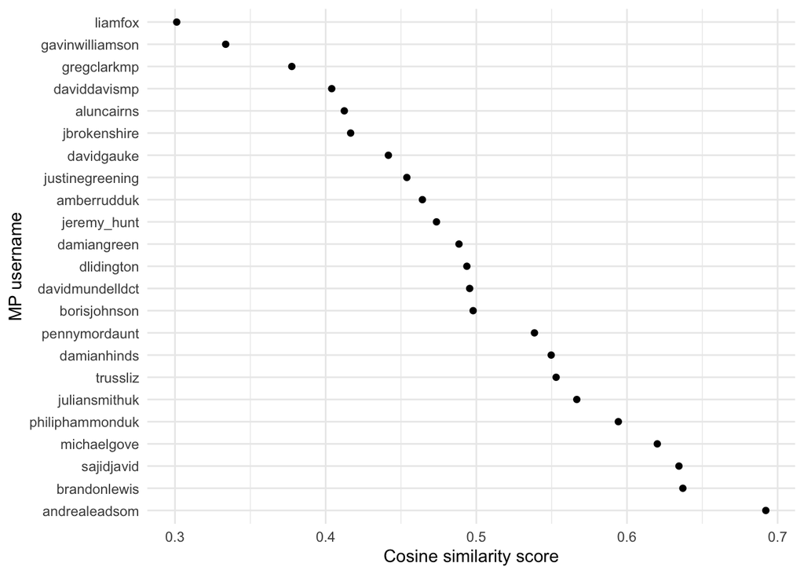

```r
ggplot(cosmatdf) +
  geom_point(aes(x=reorder(username, -corr_may), y= corr_may)) +
  coord_flip() +
  xlab("MP username") +
  ylab("Cosine similarity score") +
  theme_minimal()
```

Combining these steps into a single `for` loop, we can see how our different similarity measures of interest compare.

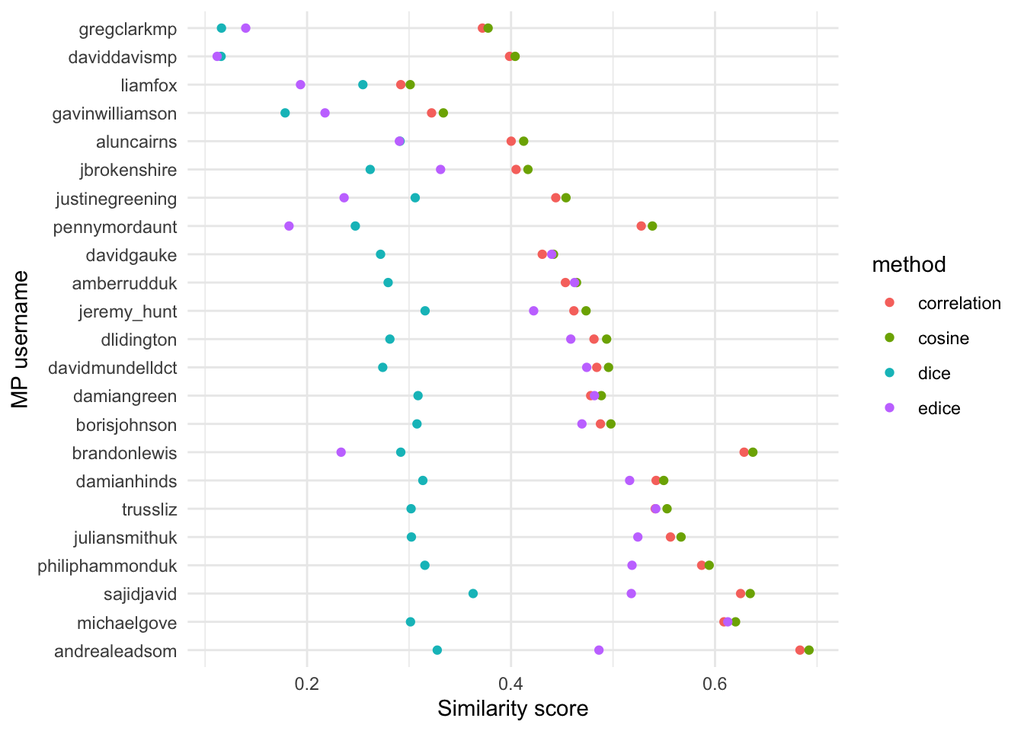

```r
#specify different similarity measures to explore
methods <- c("correlation", "cosine", "dice", "edice")

#create empty dataframe
testdf_all <- data.frame()

#gen for loop across methods types
for (i in seq_along(methods)) {

  #pass method to character string object
  sim_method <- methods[[i]]

  #estimate similarity, grouping by username
  test <- dfmat %>%
    dfm_group(groups = username) %>%
    textstat_simil(margin = "documents", method = sim_method) #specify method here as character object created above

  testm <- as.matrix(test) #convert to a matrix

  #generate data frame keeping only the row for Theresa May
  testdf <- as.data.frame(testm[23, c(1:22, 24)])

  #rename column
  colnames(testdf) <- "corr_may"

  #create column variable from rownames
  testdf <- tibble::rownames_to_column(testdf, "username")

  #record method in new column variable
  testdf$method <- sim_method

  #bind all together
  testdf_all <- rbind(testdf_all, testdf)

}

#create variable (for viz only) that is mean of similarity scores for each MP
testdf_all <- testdf_all %>%
  group_by(username) %>%
  mutate(mean_sim = mean(corr_may))

ggplot(testdf_all) +
  geom_point( aes(x=reorder(username, -mean_sim), y= corr_may, color = method)) +
  coord_flip() +
  xlab("MP username") +
  ylab("Similarity score") +
  theme_minimal()
```

## Complexity

We now move to document-level measures of text characteristics. And here we will focus on the paper by @schoonvelde_liberals_2019.

We will be using a subset of these data, taken from EU speeches given by four politicians. These are provided by the authors at https://dataverse.harvard.edu/dataset.xhtml?persistentId=doi:10.7910/DVN/S4IZ8K.

We can load the data as follows.

```r
speeches  <- readRDS(gzcon(url("https://github.com/cjbarrie/CTA-ED/blob/main/data/comparison-complexity/speeches.rds?raw=true")))
```

And we can take a look at what the data contains below.

```r
head(speeches)
```

```
##           speaker
## 1 J.L.R. Zapatero
## 2 J.L.R. Zapatero
## 3 J.L.R. Zapatero
## 4 J.L.R. Zapatero
## 5 J.L.R. Zapatero
## 6 J.L.R. Zapatero
##                                                                                                                                                                                                                                                                                                          …
## 1                                                                                                                                                                                                                                                                                                        …
## 2                                                                                                                                                                                                                                                                                                        …
## 3                                                                                                                                                                                                                                                                                                        …
## 4 President .- Good morning. Thank you for attending this press conference. I hope you all have had time to rest. In the first place, I would like to say that today is a good day for Europe and I am satisfied as we have attained a very important agreement in order to modify in a substantial way t…
## 5                                                                                                                                                                                                                                                                                                        …
## 6                                                                                                                                                                                                                                                                                                        …
```

The data contain speeches by four different politicians, each of whom are positioned at different points on a liberal-conservative scale.

We can then calculate the Flesch-Kincaid readability/complexity score with the `quanteda.textstats` package like so.

```r
speeches$flesch.kincaid <- textstat_readability(speeches$text, measure = "Flesch.Kincaid")

# returned as quanteda data.frame with document-level information;
# need just the score:
speeches$flesch.kincaid <- speeches$flesch.kincaid$Flesch.Kincaid
```

We want this information aggregated over each of our politicians: Gordon Brown, Jose Zapatero”, David Cameron, and Mariano Rajoy. These are recorded in the data under a column called “speaker.”

```r
#get mean and standard deviation of Flesch-Kincaid, and N of speeches for each speaker
sum_corpus <- speeches %>%
  group_by(speaker) %>%
  summarise(mean = mean(flesch.kincaid, na.rm=TRUE),
                   SD=sd(flesch.kincaid, na.rm=TRUE),
                   N=length(speaker))

# calculate standard errors and confidence intervals
sum_corpus$se <- sum_corpus$SD / sqrt(sum_corpus$N)
sum_corpus$min <- sum_corpus$mean - 1.96*sum_corpus$se
sum_corpus$max <- sum_corpus$mean + 1.96*sum_corpus$se
```

And this gives us data in tidy format that looks like so.

```r
sum_corpus
```

```
## # A tibble: 4 × 7
##   speaker          mean    SD     N     se   min   max
##   <chr>           <dbl> <dbl> <int>  <dbl> <dbl> <dbl>
## 1 D. Cameron       10.9  1.70   456 0.0794  10.7  11.0
## 2 G. Brown         13.3  2.28   277 0.137   13.1  13.6
## 3 J.L.R. Zapatero  15.5  2.83   354 0.150   15.2  15.8
## 4 M. Rajoy         13.7  2.56   389 0.130   13.4  13.9
```

Which we can then plot—and we see that our results look like those in Figure 1 of the published article by @schoonvelde_liberals_2019.

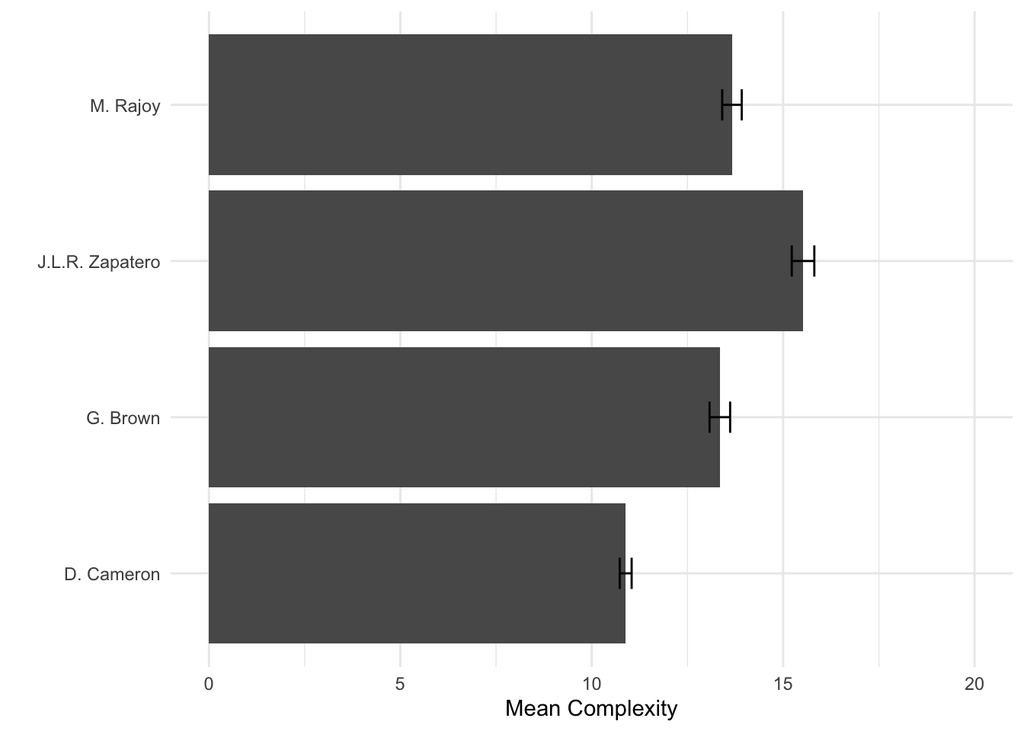

```r
ggplot(sum_corpus, aes(x=speaker, y=mean)) +
  geom_bar(stat="identity") +
  geom_errorbar(ymin=sum_corpus$min,ymax=sum_corpus$max, width=.2) +
  coord_flip() +
  xlab("") +
  ylab("Mean Complexity") +
  theme_minimal() +
  ylim(c(0,20))
```

## Exercises

1. Compute distance measures such as “euclidean” or “manhattan” for the MP tweets as above, comparing between tweets by MPs and tweets by PM, Theresa May.

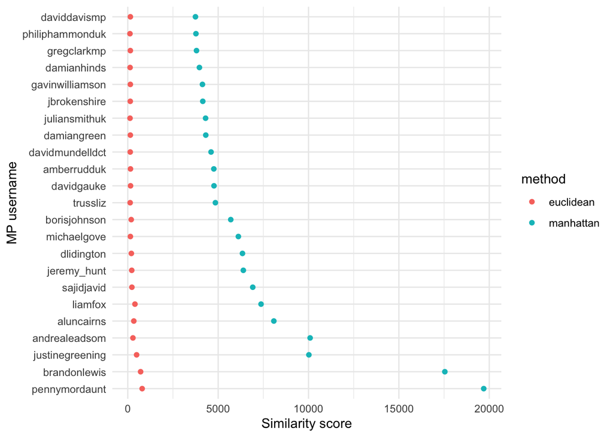

```r
#specify different similarity measures to explore
methods <- c("euclidean", "manhattan")

#create empty dataframe
testdf_all <- data.frame()

#gen for loop across methods types
for (i in seq_along(methods)) {

  #pass method to character string object
  sim_method <- methods[[i]]

  #estimate similarity, grouping by username
  test <- dfmat %>%
    dfm_group(groups = username) %>%
    textstat_dist(margin = "documents", method = sim_method) #specify method here as character object created above

  testm <- as.matrix(test) #convert to a matrix

  #generate data frame keeping only the row for Theresa May
  testdf <- as.data.frame(testm[23, c(1:22, 24)])

  #rename column
  colnames(testdf) <- "corr_may"

  #create column variable from rownames
  testdf <- tibble::rownames_to_column(testdf, "username")

  #record method in new column variable
  testdf$method <- sim_method

  #bind all together
  testdf_all <- rbind(testdf_all, testdf)

}

#create variable (for viz only) that is mean of similarity scores for each MP
testdf_all <- testdf_all %>%
  group_by(username) %>%
  mutate(mean_sim = mean(corr_may))

ggplot(testdf_all) +
  geom_point( aes(x=reorder(username, -mean_sim), y= corr_may, color = method)) +
  coord_flip() +
  xlab("MP username") +
  ylab("Similarity score") +
  theme_minimal()
```

2. Estimate at least three other complexity measures for the EU speeches as above. Consider how the results compare to the Flesch-Kincaid measure used in the article by @schoonvelde_liberals_2019.

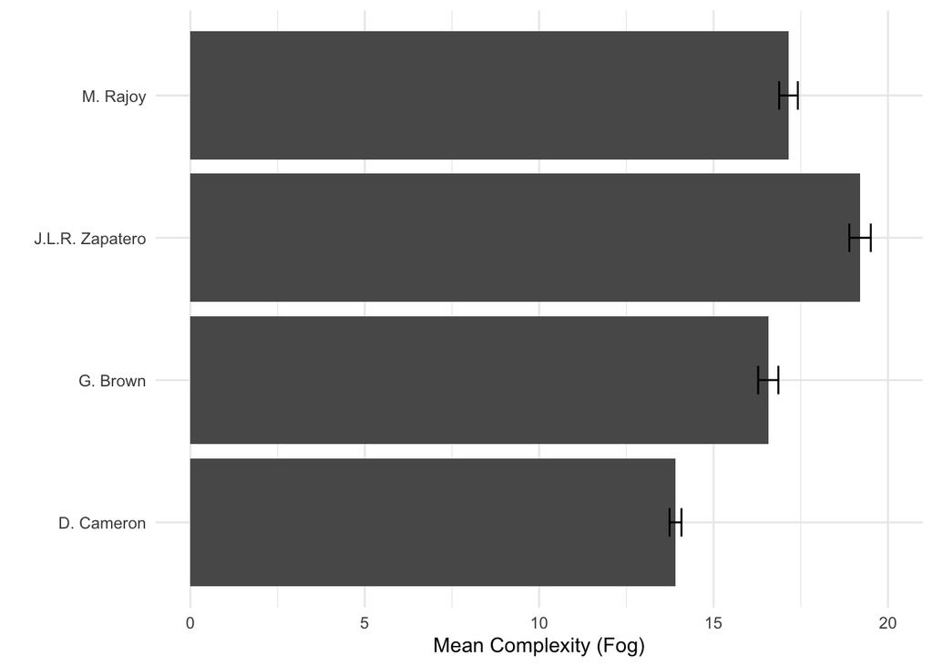

```r
speeches$fog <- textstat_readability(speeches$text, measure = "FOG")[,2] #number of 3-syllable words
speeches$ari <- textstat_readability(speeches$text, measure = "ARI")[,2] #number characters in words
speeches$drp <- textstat_readability(speeches$text, measure = "DRP")[,2] #degrees of reading power

#get mean and standard deviation of FOG
sum_corpus_fog <- speeches %>%
  group_by(speaker) %>%
  summarise(mean = mean(fog, na.rm=TRUE),
                   SD=sd(fog, na.rm=TRUE),
                   N=length(speaker))

#get mean and standard deviation of ARI
sum_corpus_ari <- speeches %>%
  group_by(speaker) %>%
  summarise(mean = mean(ari, na.rm=TRUE),
                   SD=sd(ari, na.rm=TRUE),
                   N=length(speaker))

#get mean and standard deviation of DRP
sum_corpus_drp <- speeches %>%
  group_by(speaker) %>%
  summarise(mean = mean(drp, na.rm=TRUE),
                   SD=sd(drp, na.rm=TRUE),
                   N=length(speaker))

# calculate standard errors and confidence intervals
sum_corpus_fog <- speeches %>%
  group_by(speaker) %>%
  summarise(
    mean = mean(fog, na.rm = TRUE),
    SD   = sd(fog, na.rm = TRUE),
    N    = n(),
    se   = SD / sqrt(N),
    min  = mean - (1.96 * se),
    max  = mean + (1.96 * se)
  )

sum_corpus_ari <- speeches %>%
  group_by(speaker) %>%
  summarise(
    mean = mean(ari, na.rm = TRUE),
    SD   = sd(ari, na.rm = TRUE),
    N    = n(),
    se   = SD / sqrt(N),
    min  = mean - (1.96 * se),
    max  = mean + (1.96 * se)
  )

sum_corpus_drp <- speeches %>%
  group_by(speaker) %>%
  summarise(
    mean = mean(drp, na.rm = TRUE),
    SD   = sd(drp, na.rm = TRUE),
    N    = n(),
    se   = SD / sqrt(N),
    min  = mean - (1.96 * se),
    max  = mean + (1.96 * se)
  )



ggplot(sum_corpus_fog, aes(x=speaker, y=mean)) +
  geom_bar(stat="identity") +
  geom_errorbar(ymin=sum_corpus_fog$min,ymax=sum_corpus_fog$max, width=.2) +
  coord_flip() +
  xlab("") +
  ylab("Mean Complexity (Fog)") +
  theme_minimal() +
  ylim(c(0,20))
```

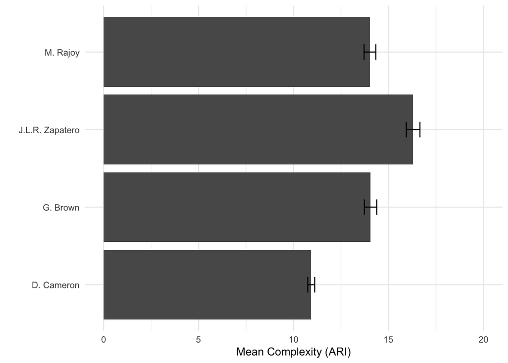

```r
ggplot(sum_corpus_ari, aes(x=speaker, y=mean)) +
  geom_bar(stat="identity") +
  geom_errorbar(ymin=sum_corpus_ari$min,ymax=sum_corpus_ari$max, width=.2) +
  coord_flip() +
  xlab("") +
  ylab("Mean Complexity (ARI)") +
  theme_minimal() +
  ylim(c(0,20))
```

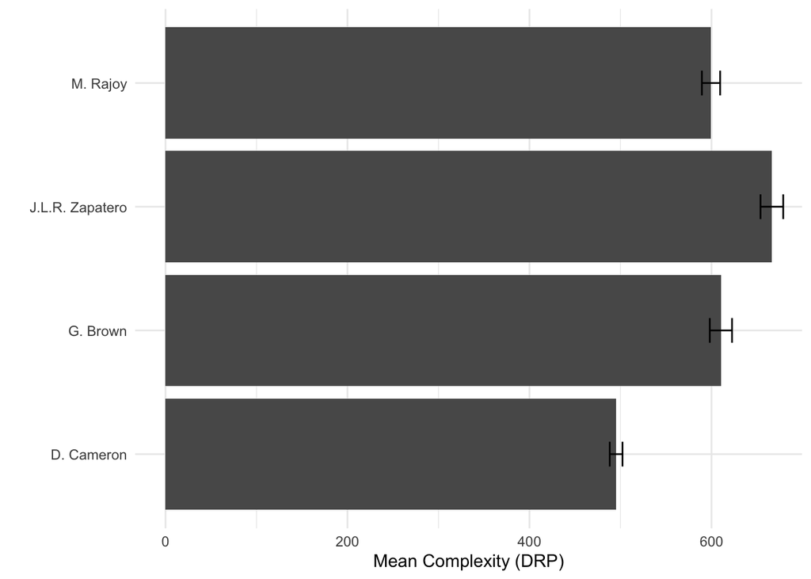

```r
ggplot(sum_corpus_drp, aes(x=speaker, y=mean)) +
  geom_bar(stat="identity") +
  geom_errorbar(ymin=sum_corpus_drp$min,ymax=sum_corpus_drp$max, width=.2) +
  coord_flip() +
  xlab("") +
  ylab("Mean Complexity (DRP)") +
  theme_minimal()
```

3. (Advanced—optional) Estimate similarity scores between the MP tweets and the PM tweets for each week contained in the data. Plot the results.